# Stat 826 Homework 2: Pest Management Trial

Alex Spicer

03/12/2020

# Goals

**Overall Goal:**

- Examine relationship between asthma symptoms and treatment in longitudinal analysis.
- Examine primary outcome using two different methods
- Visualize primary outcome overtime in treatment and control
- Visualize primary and secondary outcomes

# Executive Summary

Matsui et al.(2017) examine asthma symptoms and mice allergen levels in mice allergen sensitive children overtime in treatment and control groups. In this analysis we focus on digging deeper into the symptom analysis. The paper utilized a GEE model to look at treatment effect on symptom counts while accounting for inter-correlations imposed by the longitudinal nature of the data. We compare these results to those obtained from a standard GLM on pooled data. The results do not differ between these two models and the methods section of the paper would be better understood by a wider audience if the more simplistic GLM approach were used. Overall there appears to be not statistical difference in symptom counts over time or in treatment vs control. This would seem to indicate there is no benefit from treatment. However, it is interesting to see the steep decrease in symptoms in the first follow up for the treatment group. Thus the removal of the mice is probably very beneficial but maybe mice begin to return and the management of the mice and symptoms is the same in both groups. This agrees with the discussion in the paper regarding reduction in symptoms being most significant for those with high reduction in measured mice allergens regardless of treatment group.

# Background/Data

These data were previously published in Matsui et al.(2017) where the goal was to examine randomized clinical trial results regarding the impact of education + integrated pest control management and education alone on childhood asthma symptoms worsened by mice allergens in the home.

**Relevant Trial Information**

- **Study Location:** Boston and Baltimore
- **Study Time Frame:** May 2010 - Sept 2015
- **Eligibility:** Children in study area ages 5-17 who were mouse sensitive, exposed to mice, and had asthma
- **Treatment:** All participants received education on mouse eradication and asthma treatment/symptom control. The treatment group also received Integrated Pest Management (IPM/treatment)
- **Outcomes of Interest:** Symptom days over a 2 week period
- **Measurements:** 0,3,6,9,12 months

Data were collected on 361 children of which 334 were used in the primary analysis with 166 in the treatment group (education + IPM - referred to as IPM or treatment for simplicity) and 168 in the control group (education alone referred to as education or control).

```r
#sanity checks
#we expect 166 in the IPM + pest management and 168 in educ alone in primary analysis
length(levels(as.factor(as.character(data$ID[data$group == "Education" & data$notinprim == 0])))) #perfect
```

# Analysis

```r
set.seed(1996)
#first we need to extend notinprim
data$notinprim_all = data$notinprim

for(obs in 1:length(data$notinprim)){
  ID = data$ID[obs]
  if(data$VisitNum[obs] !=  0){
    data$notinprim_all[obs] = data$notinprim[data$ID == ID & data$VisitNum == 0]
  }

}
#now limit to those in primary analysis and visits 2-4
data_prim_anal = data[data$notinprim_all == 0 & data$VisitNum != 0 & data$VisitNum != 1 & !is.na(data$sxsmaxday) ,]
prim_outcome_gee= gee(sxsmaxday ~ group , id = ID, data = data_prim_anal, family = poisson(link = log), corstr = "exchangeable")
summary(prim_outcome_gee)

#save out info
se_gee_robust<- summary(prim_outcome_gee)$coefficients["groupIPM","Robust S.E."]
IPM_effect = round(exp(coef(prim_outcome_gee)["groupIPM"]),2)
control_mean = round(exp(coef(prim_outcome_gee)["(Intercept)"]),2)
treatment_mean = round(exp(coef(prim_outcome_gee)["groupIPM"] + coef(prim_outcome_gee)["(Intercept)"]),2)
IPM_effect_CI = round(exp(coef(prim_outcome_gee)["groupIPM"] +
 + c(-1, 1) * se_gee_robust* qnorm(0.975)),2)

#Note that the first and second columns in that row, with the median, 25th, and 75th percentiles, are also tricky. It seems like for each subject they took the average outcome across the last three visits, and that the Table 2 values are the median, 25th, and 75th percentiles of those averages

to_remove = which(duplicated(data_prim_anal$ID) == TRUE)

reduced_a = data_prim_anal[-to_remove,c("group", "ID")]
reduced_a = reduced_a[order(reduced_a$ID),]

#take mean over visit 2-4
tapply_out_a = tapply(data_prim_anal$sxsmaxday, data_prim_anal$ID, mean)
#dataframe with no missing
group_reduced_a = na.omit(data.frame(ID = row.names(tapply_out_a), sxsmaxday_mean = as.vector(tapply_out_a)))
group_reduced_a = group_reduced_a[order(group_reduced_a$ID), ]
reduced_a = cbind(group_reduced_a, reduced_a)

#save out results
educ_dist = summary(reduced_a$sxsmaxday_mean[reduced_a$group == "Education"])
lower_IQR_educ = round(educ_dist[2],1)
median_educ = round(educ_dist[3],1)
upper_IQR_educ = round(educ_dist[5],1)
treat_dist = summary(reduced_a$sxsmaxday_mean[reduced_a$group == "IPM"])
lower_IQR_treat = round(treat_dist[2],1)
median_treat = round(treat_dist[3],2)
upper_IQR_treat = round(treat_dist[5],1)
```

## Primary Outcome Summary

### Method 1: GEE

The primary outcome was maximal symptom days over a 2 week period (range 0 - 14) as assessed at 6,9, and 12 months. The dataset is given in long form with repeated measures - one row for each visit for each participant yielding multiple rows per participant. To obtain the results given in row one of table 2 (page 18 of Matsui et al.(2017)) we complete the following:

1.) Expand indicator for being in primary analysis to all rows for corresponding id (default is only listed for visit 0 but we need to know for visit 2-4)

2.) Limit dataset to those in primary analysis and eliminate observations from visit 0 and 1

3.) We are working with repeated measure count data. To handle this the authors create a generalized estimating equation (GEE) model of the form log(E[Y]) = b0 + b1*treatment. GEE is used to account for within-person correlations of the outcome by include an exchangeable correlation structure. Poisson is used as the family since the data are counts across time. Here we get a treatment effect of 0.86 with a 95% confidence interval (CI) of 0.69 to 1.06 as listed in the paper. Note this CI is based on the robust standard error output by the GEE model. The intercept tells us the mean number of symptoms over a 2 week span in the control group is 3.62 compared to 3.11 in the treatment group. However, this is not how they report the results in the paper. Rather they compute the mean number of symptoms over the 3 follow up visit for each participant and then look at the medians and interquartile range (IQR) for treatment vs control.

4.) To get the median and IQR range estimates listed in table 2 we must first reduce our dataset by taking the average number of symptoms over visits 2-4 for each participant. We use tapply to do this in R which works well except makes joining back with treatment group a bit tricky. Luckily we can use sorting by ID to do the merge. Finally we obtain the results from the table.

```r
table2 = data.frame(column = c("Treatment - Median (IQR)", "Control - Median (IQR)", "Treatment Effect (95% CI)"), estimate  = c(paste(median_treat, " (",lower_IQR_treat,"-" , upper_IQR_treat, ")", sep = ""), paste(median_educ, " (",lower_IQR_educ,"-" , upper_IQR_educ, ")", sep = ""), paste(IPM_effect, " (",IPM_effect_CI[1],"-" , IPM_effect_CI[2], ")", sep = "")))


kable(table2, caption = "Replication of Table 2 line 1")%>%
  kable_styling(bootstrap_options = c("striped", "hover", "condensed"), full_width = F)
```

Replication of Table 2 line 1

| column | estimate |
| --- | --- |
| Treatment - Median (IQR) | 2 (0.7-4.7) |
| Control - Median (IQR) | 2.7 (1.3-5) |
| Treatment Effect (95% CI) | 0.86 (0.69-1.06) |

```r
#using GLM

#will only have one row per person now
data_prim_anal_sum = data[data$notinprim_all == 0 & data$VisitNum != 0 & data$VisitNum != 1 & !is.na(data$VisitNum), ]
ids_with_miss = unique(as.character(data_prim_anal_sum$ID[which(is.na(data_prim_anal_sum$sxsmaxday))]))
to_drop = which(data_prim_anal_sum$ID %in% ids_with_miss)
data_prim_anal_sum = data_prim_anal_sum[-c(to_drop),]

#sum over visits
tapply_out_test = tapply(data_prim_anal_sum$VisitNum, data_prim_anal_sum$ID, sum)
ids_with_miss_visit = row.names(tapply_out_test[which(tapply_out_test != 9)])
to_drop2 = which(data_prim_anal_sum$ID %in% ids_with_miss_visit)
data_prim_anal_sum = data_prim_anal_sum[-c(to_drop2),]
tapply_out_b = tapply(data_prim_anal_sum$sxsmaxday, data_prim_anal_sum$ID, sum)
data_reduced = na.omit(data.frame(ID = row.names(tapply_out_b), sxsmaxday_sum = as.vector(tapply_out_b)))


data_reduced = na.omit(merge(data_reduced,data[,c("ID", "group")], by = c("ID"), all.y = TRUE ))
data_reduced = data_reduced[duplicated(data_reduced$ID)==FALSE,]
#build model
prim_outcome_glm = glm(sxsmaxday_sum ~ group, data = data_reduced, family = quasipoisson(link = log))
#summary(prim_outcome_glm)

#save output
treat_se_glm = summary(prim_outcome_glm)$coefficients[2,2]
IPM_effect_glm = round(exp(coef(prim_outcome_glm)["groupIPM"]),2)
treatment_mean_glm = round(exp(coef(prim_outcome_glm)["(Intercept)"] + coef(prim_outcome_glm)["groupIPM"])/3,2)
control_mean_glm = round(exp(coef(prim_outcome_glm)["(Intercept)"])/3,2)
IPM_effect_glm_CI = round(exp(coef(prim_outcome_glm)["groupIPM"] +
 + c(-1, 1) * treat_se_glm* qnorm(0.975)),2)

# IPM_effect_glm
# IPM_effect_glm_CI

#make dataframe with output from GLM and GEE for plotting
table2_model_comp = data.frame(model_type = c("GEE", "GLM"), treatment_effect = c(IPM_effect, IPM_effect_glm), lower_lim = c(IPM_effect_CI[1],IPM_effect_glm_CI[1]), upper_lim = c(IPM_effect_CI[2], IPM_effect_glm_CI[2]))
```

### Method 2: GLM

Just as the authors simplified the reporting of the median symptom values by pooling across weeks, the modeling portion described above could be simplified by pooling before fitting as well. However, instead of using mean we will sum the symptoms across visit counts for each participant and included only those with data for visits 2-4. The Poisson distribution assumes that the mean and variance are equal. However, this is unlikely to be the case and therefore we use Quasi-Poisson to account for over-dispersion and allow the variance to be a linear function of the mean. Looking at these results we get a treatment effect of 0.88 with a 95% confidence interval of 0.71 to 1.1.

### Method Comparison

As one can see in figure 1 the estimates from the GEE and the pooled GLM model are nearly the same and the standard errors overlap significantly with the GLM model having a slightly wider CI with a range of 0.71 - 1.1 compared to 0.69 - 1.06 in the GEE. This may be due to the ability of the GEE model to better capture between visit effects making the estimate of the standard error lower.

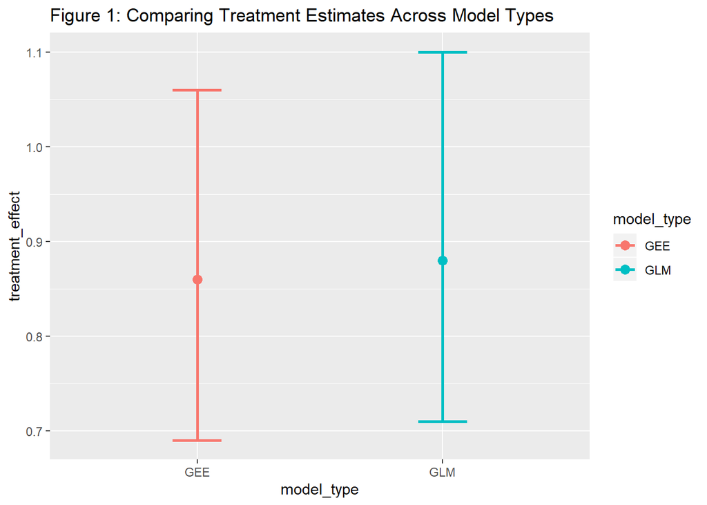

```r
#st error plot odds ratio estimate GEE vs GLM
ggplot(table2_model_comp, aes(x=model_type, y=treatment_effect, color=model_type, group = 1)) +
  geom_point(size = 3)+
  geom_errorbar(aes(ymin=lower_lim, ymax=upper_lim), width=.2, size = 1,
                 position=position_dodge(0.05))+ggtitle("Figure 1: Comparing Treatment Estimates Across Model Types")
```

### Comments

Finally, a few comments on the analysis in the paper.

1.) The method used to obtain the estimates in table 2 is poorly described.

2.) The protocol says that site will be included as a predictor but this is not the case as we reproduced the estimate without this variable.

3.) The analysis seems over complicated as few are familiar with a GEE model and the pooled GLM gives comparable results.

5.) No method found any statistically significant difference in primary outcome between treatment and control.

## Primary Outcome Overtime

In the second to last paragraph of the paper’s discussion they mention the success of a large reduction in home mouse allergens as well as a reduction in asthma symptoms. We want to explore this reduction in symptoms over time to see the magnitude, timing, and to compare IPM to education alone. In order to do this I first chose a sequenced panel of box-plots showing the distribution of symptom counts at each time-point. I chose this graph as the box-plots allow the viewer to get a sense of the variance in the distribution. One can also easily look at the median values and extreme values across time-points. I chose to have the graphs for control and treatment one above the other for easier comparison of a given time-point compared to side-by-side placement. I chose the colors to match the second plot. This plot pair reveals greater variance in symptoms observed (larger IQR range) for the education alone compared to the treatment group. The reduction in symptoms across time attains about the same level in treatment vs control by month 12 but in the IPM group the reduction is immediate and then holds steady. The control group appears to have a slightly higher baseline and the greatest reduction surprisingly between months 9 and 12.

```r
#rename to reflect timescale better
#0: baseline ; 1: 3month; 2: 6month ; 3: 9month ; 4: 12month

data$months = NA
data$months[data$VisitNum == 0] = 0
data$months[data$VisitNum == 1] = 3
data$months[data$VisitNum == 2] = 6
data$months[data$VisitNum == 3] = 9
data$months[data$VisitNum == 4] = 12
data$months = as.factor(data$months)

#some people do not get the intervention every month
#summary(data$months[(data$intervention)==1])

data$group_v2 = data$group
data$group_v2[data$intervention == 0] = "Education"
#summary(data$group)
#summary(data$group_v2)
```

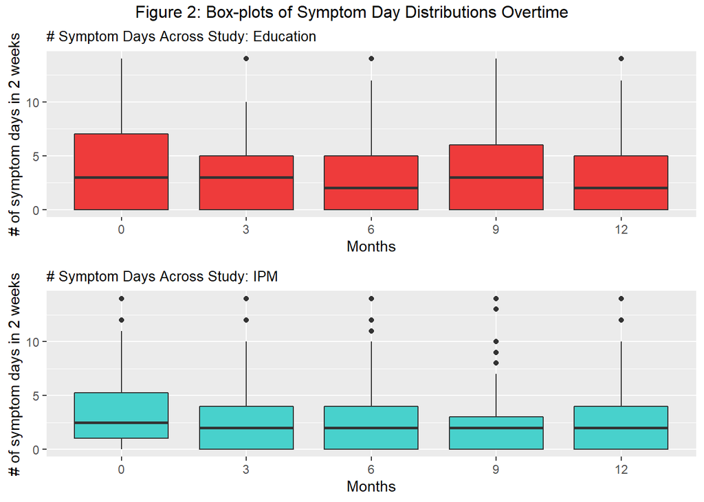

```r
#2 boxplot series
control_boxplots = ggplot(data[data$group == "Education",], aes(x = months, y=sxsmaxday, group = as.factor(months), fill = group)) + geom_boxplot() + scale_fill_manual(values=c("brown2"))+ theme(legend.position= "none")+ylab("# of symptom days in 2 weeks")+xlab("Months")+ggtitle("# Symptom Days Across Study: Education") +  theme(plot.title = element_text(size = 10))

education_boxplots = ggplot(data[data$group == "IPM",], aes(x = months, y=sxsmaxday, group = as.factor(months), fill = group) )+ geom_boxplot() + scale_fill_manual(values=c("mediumturquoise"))+ theme(legend.position= "none")+ylab("# of symptom days in 2 weeks")+xlab("Months")+ggtitle("# Symptom Days Across Study: IPM")  +  theme(plot.title = element_text(size = 10))

grid.arrange(control_boxplots, education_boxplots, ncol=1,
               top="Figure 2: Box-plots of Symptom Day Distributions Overtime")
```

```r
#let's do a t-test to see if there is a difference accross visit times

educ_baseline = data.frame( ID = data$ID[data$group == "Education" & data$VisitNum == 0], sxsmaxday_visit0 = log(data$sxsmaxday[order(data$ID[data$group == "Education" & data$VisitNum == 0])]+1))
educ_followup =  data.frame( ID = data$ID[data$group == "Education" & data$VisitNum == 4], sxsmaxday_visit4 = log(data$sxsmaxday[order(data$ID[data$group == "Education" & data$VisitNum == 4])]+1))
educ_ttest = merge(educ_baseline, educ_followup, by = c("ID"))
educ_ttest_out = t.test(x = educ_ttest[,2], y = educ_ttest[,3], paired = TRUE)


IPM_baseline = data.frame( ID = data$ID[data$group == "IPM" & data$VisitNum == 0], sxsmaxday_visit0 = log(data$sxsmaxday[order(data$ID[data$group == "IPM" & data$VisitNum == 0])]+1))
IPM_followup =  data.frame( ID = data$ID[data$group == "IPM" & data$VisitNum == 4], sxsmaxday_visit4 = log(data$sxsmaxday[order(data$ID[data$group == "IPM" & data$VisitNum == 4])]+1))
IPM_ttest = merge(IPM_baseline, IPM_followup, by = c("ID"))
IPM_ttest_out =t.test(x = IPM_ttest[,2], y = IPM_ttest[,3], paired = TRUE)
```

To visualize this trend more easily and compare the treatment and control groups directly I chose to use a line graph where I plot the mean number of symptoms for each time point for each treatment and then fit a loess (locally weighted smoothing) function. This non-parametric method does not require any distributional assumptions and fits the data by weighting to the nearest data point. It also allows the estimation of standard errors as shown by the gray shaded area. The colors correspond with the box-plots. This graph clearly shows the initial steep decrease in symptoms for the treatment group and the slight rise afterward. This may be due to the extermination of the mice eliminating allergens but then the slight re-occurrence until the mice control method is implemented by the family. It is very odd in the education group that there is such a spike at month 9. However, the standard errors are large so we should not read too much into this. The standard errors also reveal the lack of difference between treatment and control. Further, note that the difference in symptoms across the study time period is less than one symptom day in both groups although the confidence intervals do show that the reduction from baseline to 12 months is most likely not significant (lower level of CI for baseline does not include estimates at 12 months but CI’s at 0 and 12 still overlap for both groups). Performing a paired t-test to compare symptom counts between baseline and month 12 we get a p-value of 0.63 and 0.98 for treatment vs control respectively indicating no significant difference between baseline and 12 months in either group. This agrees with the results in the paper as they only state a significant reduction in symptoms overtime when there was a sizable decrease in mice allergens present in the home.

A lot of the same information can be gained from both of these plots like the overall trend and lack of significance of treatment effect. However I think the box-plots best show the higher variance in the control group and the line graph best shows the trend over time in both groups.

Also note that some people in the treatment group did not recieve the treatment at everytime point (summarized in intervention variable). I am not sure if this is because they had no mice to get ride of or if they were unavailable. If future analyses are conducted, especially those focusing on mice allergen levels in the home, this could be interesting to examine.

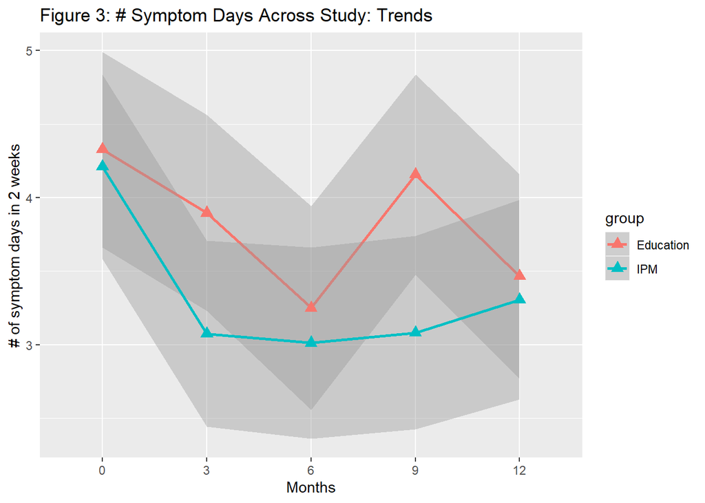

```r
#trend line plot with loess


ggplot(data, aes(x = months, y = sxsmaxday), group = group)+stat_smooth(aes(group = group, color = group)) + stat_summary(aes(group = group, color = group),
    geom = "point", fun.y = mean, shape = 17, size = 3)+ylab("# of symptom days in 2 weeks")+xlab("Months")+ggtitle("Figure 3: # Symptom Days Across Study: Trends")
```

## Secondary Outcomes

There are a number of secondary outcomes of interest in this analysis relating to counts of specific symptoms contributing to the primary outcome (overall symptom count). These results are displayed in table 2 of the paper. However, there are a lot of numbers and it is hard to draw any conclusions. I think there are two main points of interest in the table 1.) What if any difference in symptoms are there between treatment and control? and 2.) How do the different symptoms contribute in overall count?

To visualize the treatment effect for each symptom I chose an odds ratio plot. Each point is the treatment affect and the lines span the 95% CI. Here we can see the treatment effect estimates as well as the CI’s for these effects. If the CI spans the dashed line at 1 there is no statistically significant difference in symptom counts between treatment and control. I chose this methods as I think at first glance you can see that none of the symptoms are significantly different although slowed activity due to asthma is close. If there were any significant differences I could use color to more directly indicate this. Here I am not making use of color to differentiate symptoms but if there was a grouping inherent in the data I would use color. I chose purple since blue and red make purple and these ratios contain information from both the treatment and control groups represented with blue and red respectively throughout this analysis.

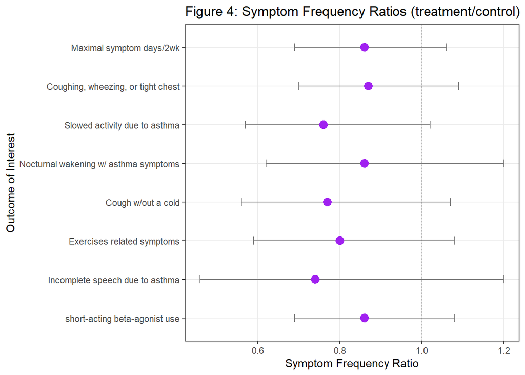

```r
#data from table 2 in paper - column 3
data_table2 = data.frame(outcome = factor(c("Maximal symptom days/2wk", "Coughing, wheezing, or tight chest", "Slowed activity due to asthma", "Nocturnal wakening w/ asthma symptoms", "Cough w/out a cold", "Exercises related symptoms", "Incomplete speech due to asthma", "short-acting beta-agonist use"), order = TRUE, levels = rev(c("Maximal symptom days/2wk", "Coughing, wheezing, or tight chest", "Slowed activity due to asthma", "Nocturnal wakening w/ asthma symptoms", "Cough w/out a cold", "Exercises related symptoms", "Incomplete speech due to asthma", "short-acting beta-agonist use"))), ratio_estimate = c(0.86, 0.87, 0.76, 0.86, 0.77, 0.80, 0.74, 0.86), conf.low = c(0.69, 0.70, 0.57, 0.62, 0.56, 0.59, 0.46, 0.69), conf.high = c(1.06, 1.09, 1.02, 1.20, 1.07, 1.08, 1.2, 1.08))

#plot
ggplot(data_table2, aes(x = ratio_estimate, y = outcome))  + geom_vline(aes(xintercept = 1), size = .25, linetype = "dashed") +
geom_errorbarh(aes(xmax = conf.high, xmin = conf.low), size = .5, height =
.2, color = "gray50") +
 geom_point(size = 3.5, color = "purple") +
 theme_bw() +
 theme(panel.grid.minor = element_blank()) +
 ylab("Outcome of Interest") +
 xlab("Symptom Frequency Ratio") + ggtitle("Figure 4: Symptom Frequency Ratios (treatment/control)")+theme(legend.title = element_blank())
```

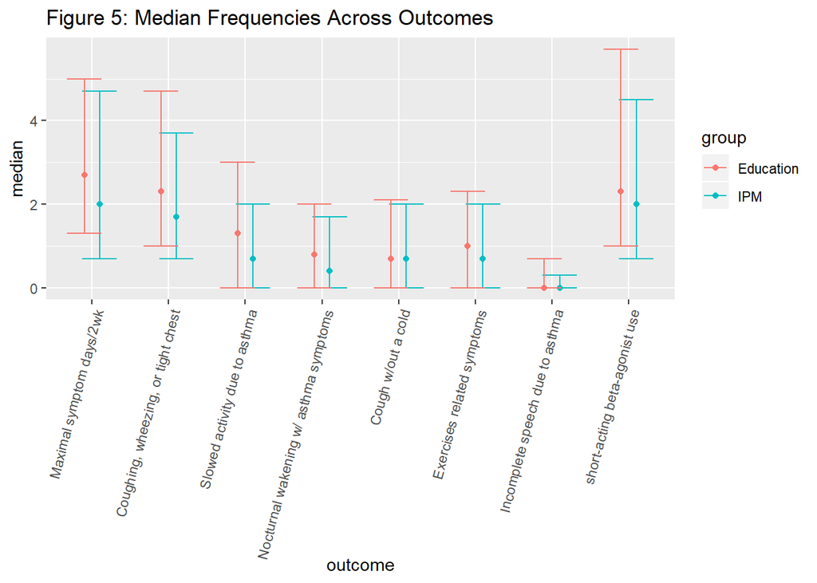

```r
#data from table 2 in paper column 1 and 2
data_table2_long = data.frame(outcome = factor(c("Maximal symptom days/2wk","Maximal symptom days/2wk", "Coughing, wheezing, or tight chest","Coughing, wheezing, or tight chest", "Slowed activity due to asthma", "Slowed activity due to asthma","Nocturnal wakening w/ asthma symptoms", "Nocturnal wakening w/ asthma symptoms", "Cough w/out a cold", "Cough w/out a cold","Exercises related symptoms", "Exercises related symptoms","Incomplete speech due to asthma", "Incomplete speech due to asthma","short-acting beta-agonist use", "short-acting beta-agonist use"), order = TRUE, levels = c("Maximal symptom days/2wk", "Coughing, wheezing, or tight chest", "Slowed activity due to asthma", "Nocturnal wakening w/ asthma symptoms", "Cough w/out a cold", "Exercises related symptoms", "Incomplete speech due to asthma", "short-acting beta-agonist use")), order_num = c(1,2,3,4,5,6,7,8,1.5,2.5, 3.5,4.5, 5.5,6.5,7.5,8.5), median = c(2,2.7,1.7,2.3,0.7, 1.3, 0.4, 0.8, 0.7,0.7,0.7,1,0,0,2,2.3), group = rep(c("IPM", "Education"),8), conf.low = c(.7,1.3, 0.7, 1,0,0,0,0,0,0,0,0,0,0,.7,1), conf.high = c(4.7, 5,3.7,4.7, 2,3,1.7,2,2,2.1,2,2.3,.3,.7,4.5,5.7))

#plot
ggplot(data_table2_long, aes(y = median, x = outcome, group = group, color = group))+geom_point(position=position_dodge(width = .4))+geom_errorbar(aes(ymin=conf.low, ymax=conf.high),position=position_dodge(width = .4))+ggtitle("Figure 5: Median Frequencies Across Outcomes")+ theme(axis.text.x = element_text(angle = 75, hjust = 1))
```

# Conclusions

This study looks at the impact of intervention and education vs education alone on asthma symptoms in mice allergen sensitive children. The paper utilized a GEE model to account for inter-correlations due to the longitudinal nature of the data. However in performing a standard GLM on pooled data the results did not differ and the methods would be simpler if this approach were used. Overall there appears to be no statistically significant difference in symptom counts over time or in treatment vs control. This would seem to indicate there is no benefit in IPM. Yet, it is interesting to see the steep decrease in symptoms in the first follow up for the treatment group. Thus the removal of the mice is probably very beneficial but maybe mice begin to return and the management of the mice and symptoms is the same in both groups.